# Descriptive Statistics and Decision Tree

### Q.4.b) Visualize a few other numerical variables in the dataset and discuss any interesting features. When describing distributions of numerical variables we might also want to view statistics like mean, median, etc.

```r
summary(diamonds)
```

```
##      carat               cut        color        clarity
##  Min.   :0.2000   Fair     : 1610   D: 6775   SI1    :13065
##  1st Qu.:0.4000   Good     : 4906   E: 9797   VS2    :12258
##  Median :0.7000   Very Good:12082   F: 9542   SI2    : 9194
##  Mean   :0.7979   Premium  :13791   G:11292   VS1    : 8171
##  3rd Qu.:1.0400   Ideal    :21551   H: 8304   VVS2   : 5066
##  Max.   :5.0100                     I: 5422   VVS1   : 3655
##                                     J: 2808   (Other): 2531
##      depth           table           price             x
##  Min.   :43.00   Min.   :43.00   Min.   :  326   Min.   : 0.000
##  1st Qu.:61.00   1st Qu.:56.00   1st Qu.:  950   1st Qu.: 4.710
##  Median :61.80   Median :57.00   Median : 2401   Median : 5.700
##  Mean   :61.75   Mean   :57.46   Mean   : 3933   Mean   : 5.731
##  3rd Qu.:62.50   3rd Qu.:59.00   3rd Qu.: 5324   3rd Qu.: 6.540
##  Max.   :79.00   Max.   :95.00   Max.   :18823   Max.   :10.740
##
##        y                z
##  Min.   : 0.000   Min.   : 0.000
##  1st Qu.: 4.720   1st Qu.: 2.910
##  Median : 5.710   Median : 3.530
##  Mean   : 5.735   Mean   : 3.539
##  3rd Qu.: 6.540   3rd Qu.: 4.040
##  Max.   :58.900   Max.   :31.800
##
```

[figure not shown]

```r
p<- ggplot(diamonds,aes(x=cut,y=carat))
p+ geom_boxplot(fill="darkblue",colour="red")+ggtitle("Histogram of Price of diamonds")+#points(diamonds$cut, means$carat, col = "red")+
  stat_summary(fun.y=mean, geom="point",colour="red",shape=19,size=4)
```

### Q.4.c) What type of variable is color? Which color is most prominently represented in the dataset?

```r
str(diamonds$color)
```

```
##  Ord.factor w/ 7 levels "D"<"E"<"F"<"G"<..: 2 2 2 6 7 7 6 5 2 5 ...
```

```r
#colour is a variable of type factor with 7 levels. COlor G is most prominantly represented in dataset.
```

### Q.4.d) Make a bar plot of the distribution of cut, and describe its distribution (Use georm bar())

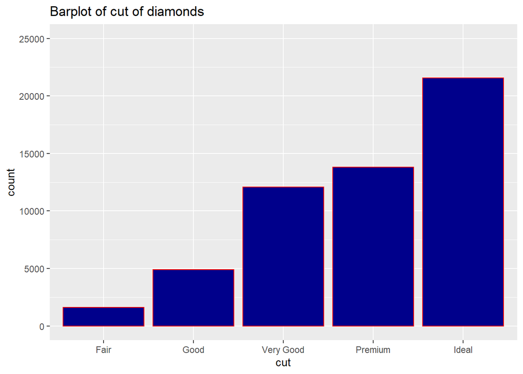

```r
b<- ggplot(diamonds,aes(x=cut))
b+ geom_bar(fill="darkblue",colour="red")+ggtitle("Barplot of cut of diamonds")+ylim(0,25000)
```

```r
#The graph tells that the frequency of diamonds is increasing as the cut is getting ideal.
```

### Q.4.e) Make a histogram of the depths of diamonds, with binwidth of 0.2%, and add another variable (say, cut) to the visualization. You can do this either using an aesthetic or a facet. Typical diamonds of which cut have the highest depth? On average, does depth increase or decrease as cut grade increase or decrease?

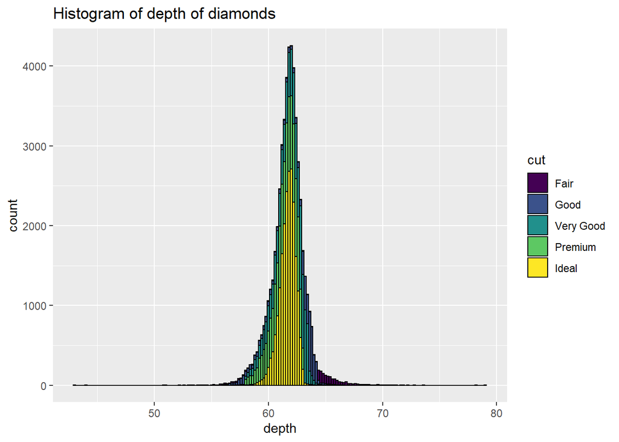

```r
b<- ggplot(diamonds,aes(x=depth))
b+ geom_histogram(binwidth=0.2,aes(fill=cut),colour="black")+ggtitle("Histogram of depth of diamonds")#+ylim(0,15000)
```

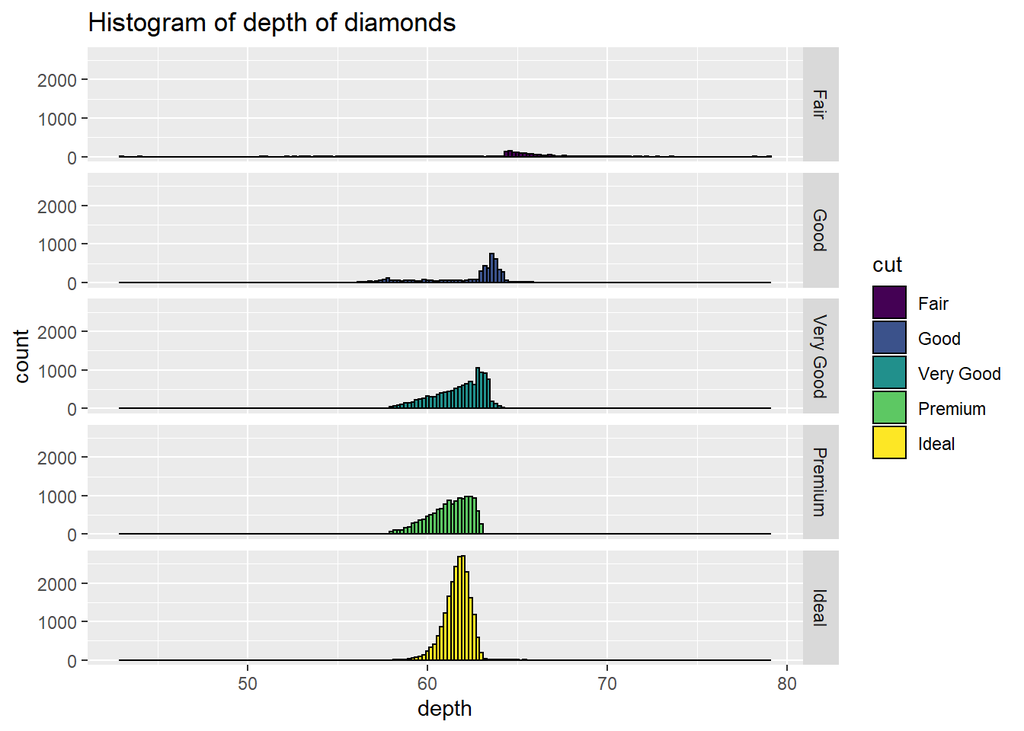

```r
#By facet_grid

b+ geom_histogram(binwidth=0.2,aes(fill=cut),colour="black")+ggtitle("Histogram of depth of diamonds")+
  facet_grid(cut~.)
```

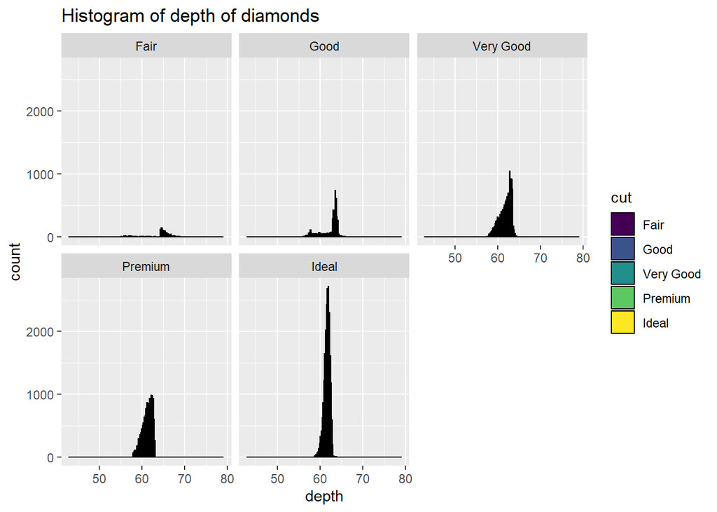

```r
#By facet_wrap

b+ geom_histogram(binwidth=0.2,aes(fill=cut),colour="black")+ggtitle("Histogram of depth of diamonds")+
  facet_wrap(cut~.)
```

```r
#As the cut ibecomes better the depth reduces
```